# SINADEF 2.0

## Parte 3: por edades

```r
muertos <- nrow(x)
```

```r
(x_edad <-
    count(x, EDAD_DECLARADA, sort=T) %>%
    mutate(p  = round(n/muertos* 100,4))
)
```

| EDAD_DECLARADA | n | p |
| --- | --- | --- |
| 66 | 5566 | 2.6891 |
| 67 | 5462 | 2.6389 |
| 65 | 5455 | 2.6355 |
| 68 | 5424 | 2.6205 |
| 70 | 5332 | 2.5760 |
| 72 | 5284 | 2.5529 |
| 73 | 5275 | 2.5485 |
| 69 | 5237 | 2.5301 |
| 74 | 5167 | 2.4963 |
| 64 | 5160 | 2.4929 |

[output cut: 105 more lines]

Grupos de riesgo segun el MINSA https://www.datosabiertos.gob.pe/dataset/tabla-de-grupo-de-riesgo 5 - 12 Personas de 12 a 17 años Personas de 18 a 19 años Personas de 20 a 29 años Personas de 30 a 39 años Personas de 40 a 49 años Personas de 50 a 59 años 60 años a más 60 años a más, Adulto Mayor

```r
x <- x %>%
    mutate(
        grupo = case_when(
            between(EDAD_DECLARADA, 60, 120) ~ "60+",
            between(EDAD_DECLARADA, 50, 59) ~ "50-59",
            between(EDAD_DECLARADA, 40, 49) ~ "40-49",
            between(EDAD_DECLARADA, 30, 39) ~ "30-39",
            between(EDAD_DECLARADA, 18, 29) ~ "18-29",
            between(EDAD_DECLARADA, 13, 17) ~ "13-17",
            between(EDAD_DECLARADA, 5, 12) ~ "5-12",
            between(EDAD_DECLARADA, 0, 4) ~ "0-4"
        )
    )
```

Cifras finales por grupos

```r
x %>%
    count(grupo,sort=T) %>%
    mutate(p  = round(n/muertos* 100, 4)) %>%
    rename(`Grupo`=grupo, `Total de muertos`=n,  `Porcentaje del total` = p)
```

| Grupo | Total de muertos | Porcentaje del total |
| --- | --- | --- |
| 60+ | 143973 | 69.5576 |
| 50-59 | 34737 | 16.7825 |
| 40-49 | 17381 | 8.3973 |
| 30-39 | 7022 | 3.3925 |
| 18-29 | 2616 | 1.2639 |
| 0-4 | 544 | 0.2628 |
| 5-12 | 388 | 0.1875 |
| 13-17 | 321 | 0.1551 |
| NA | 2 | 0.0010 |

Cifras de criterios de definicion de muertes en los grupos jovenes “0-4”, “5-12”, “13-17”

```r
filter(x, grupo %in% c("0-4", "5-12", "13-17")  ) %>%
    count(CLASIFICACION_DEF,sort=T) %>%
    ungroup() %>%
    mutate(
        p= round(n/sum(n)*100,4),
        CLASIFICACION_DEF = str_replace(CLASIFICACION_DEF, "Ã³", "ó") %>% str_replace("Ã", "í")
    ) %>%
    rename(`Definición muerte por Covid` = CLASIFICACION_DEF, `Total de muertos`=n,  `Porcentaje del total` = p)
```

| Definición muerte por Covid | Total de muertos | Porcentaje del total |
| --- | --- | --- |
| Criterio clínico | 394 | 31.4445 |
| Criterio SINADEF | 346 | 27.6137 |
| Criterio serológico | 220 | 17.5579 |
| Criterio virológico | 166 | 13.2482 |
| Criterio investigación Epidemiolí³gica | 75 | 5.9856 |
| Criterio nexo epidemiológico | 31 | 2.4741 |
| Criterio radiológico | 21 | 1.6760 |

```r
NA
```

### Analisis TODO: ver como evolucionan los criterios de evaluacion

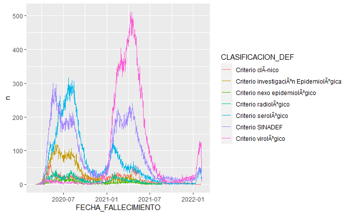

```r
count(x, FECHA_FALLECIMIENTO, CLASIFICACION_DEF) %>%
    ggplot() +
    geom_line(aes(x=FECHA_FALLECIMIENTO, y = n, color=CLASIFICACION_DEF))
```